# Headline-Grabber

Insurance  
**Headline-Grabber** 🤖

Welcome to the latest Insurance **Headline-Grabber** issue. We grabbed **15** headlines **between the dates** **2024-08-31** (exclusive) and **2024-09-06** (inclusive).

Check Headline Sources at End

| Header | Entry |
| --- | --- |
| Source | Association of British Insurers |
| Sub Source | News |
| Title | TV’s Gemma Collins calls for pension attention with parody face cream ad |
| Publication Date | 2024-09-06 |
| Link | [Click here for the headline source](https://www.abi.org.uk/news/news-articles/2024/9/tvs-gemma-collins-calls-for-pension-attention-with-parody-face-cream-ad/) |
| Description | TV star and pensions newbie, Gemma Collins is taking over the pensions megaphone for 2024 and calling on the nation to face their future with confidence and pay their pension some attention. |
| NA | NA |
| Source | Eurostat |
| Sub Source | Euro Indicators |
| Title | Services production down by 0.8% in the euro area and by 0.9% in the EU |
| Publication Date | 2024-09-06 |
| Link | [Click here for the headline source](https://ec.europa.eu/eurostat/product?code=4-06092024-bp) |
| Description | In June 2024, compared with May 2024, seasonally adjusted services production decreased by 0.8% in the euro area and by 0.9% in the EU, according to first estimates from Eurostat, the statistical offi… |
| NA | NA |
| Source | Eurostat |
| Sub Source | Euro Indicators |
| Title | GDP up by 0.2% and employment up by 0.2% in the euro area |
| Publication Date | 2024-09-06 |
| Link | [Click here for the headline source](https://ec.europa.eu/eurostat/product?code=2-06092024-ap) |
| Description | Following recommendations for a harmonised European revision policy for national accounts and balance of payments, EU countries are carrying out a benchmark revision of their national accounts estimat… |
| NA | NA |
| Source | Eurostat |
| Sub Source | Euro Indicators |
| Title | Volume of retail trade up by 0.1% in the euro area and by 0.2% in the EU |
| Publication Date | 2024-09-05 |
| Link | [Click here for the headline source](https://ec.europa.eu/eurostat/product?code=4-05092024-ap) |
| Description | In July 2024, compared with June 2024, the seasonally adjusted retail trade volume increased by 0.1% in the euro area and by 0.2% in the EU, according to first estimates from Eurostat, the statistical… |
| NA | NA |
| Source | Financial Conduct Authority |
| Sub Source | News |

[output cut: 75 more lines]

**Spot Light**

This red box is reserved for spotlight articles suggested by the community.

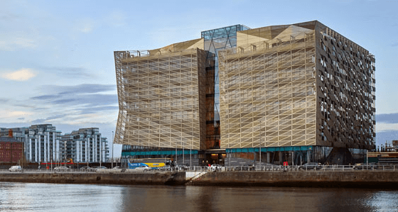

Last week the CBI issued a **Dear CEO** letter to the insurance industry discussing their recently completed targeted Consumer Protection Risk Assessment (CPRA). Check it out at the link below:

[Click here for the headline source](https://www.centralbank.ie/docs/default-source/regulation/consumer-protection/compliance-monitoring/themed-inspections/industry-letter---targeted-consumer-protection-risk-assessment.pdf)

Headline Sources

**Below are the sites that have been monitored in this issue, and the number of headlines grabbed:**

- **Ireland News**
  - Central Bank of Ireland - [Press Release](https://www.centralbank.ie/news-media/press-releases) (0)
  - Health Insurance Authority - [Press Release](https://www.hia.ie/publications/press-releases) (0)
  - Insurance Ireland - [News](https://insuranceireland.eu/news-and-publications/news-press-release/) (0)
  - Society of Actuaries Ireland - [Submissions](https://web.actuaries.ie/category/submission) (0)
  - Irish Brokers Association - [News](https://brokersireland.ie/news/) (Coming Soon)
- **UK News**
  - Financial Conduct Authority - [News](https://www.fca.org.uk/news/search-results?n_search_term=&category=news%20stories&sort_by=dmetaZ) (2)
  - Bank of England - [News](https://www.bankofengland.co.uk/news/prudential-regulation) (0)
  - Association of British Insurers - [News](https://www.abi.org.uk/news/news-articles/) (3)
  - Institute and Faculty of Actuaries - [News](https://www.actuaries.org.uk/news-insights) (0)
  - Lloyds of London - [News](https://www.lloyds.com/news-and-insights/news) (Coming Soon)
- **European News**
  - EIOPA
    - [News](https://www.eiopa.europa.eu/media/news_en) (3)
    - [Q and A](https://www.eiopa.europa.eu/search-qas_en) (0)
  - Insurance Europe - [News](https://www.insuranceeurope.eu/search?sort=date&type[news]=1&page=1) (1)
  - Actuarial Association of Europe - [News](https://actuary.eu/category/aae-news/) (2)
  - Eurostat - [Euro Indicators](https://ec.europa.eu/eurostat/en/web/main/news/euro-indicators) (4)
  - European Commission - [Publications](https://commission.europa.eu/publications_en) (Coming Soon)
- **International News**
  - IFRS Foundation - [News](https://www.ifrs.org/news-and-events/news/) (Coming Soon)
  - International Association of Insurance Supervisors (IAIS) - [News](https://www.iaisweb.org/news-and-events/latest-news/) (Coming Soon)
  - Casualty Actuarial Society (US) - [News](https://www.casact.org/news) (Coming Soon)
  - Society of Actuaries (US) - [News](https://www.soa.org/resources/newsroom/default/) (Coming Soon)
- **Suggest Sources:** mark@headline-grabber.com

[figure not shown]

Be Informed, Stay Informed

[Terms and Conditions](https://headline-grabber.com/t%26cs)

**Suggest Sources:** mark@headline-grabber.com